# Titanic dataset

First, we will load and perhpas clean the data a bit, by removing the first column as it is unnecessary and convert a few of the variables into factors.

```r
titanic = read.csv('/Users/LT/Downloads/train.csv')
str(titanic)
```

```
## 'data.frame':    891 obs. of  12 variables:
##  $ PassengerId: int  1 2 3 4 5 6 7 8 9 10 ...
##  $ Survived   : int  0 1 1 1 0 0 0 0 1 1 ...
##  $ Pclass     : int  3 1 3 1 3 3 1 3 3 2 ...
##  $ Name       : chr  "Braund, Mr. Owen Harris" "Cumings, Mrs. John Bradley (Florence Briggs Thayer)" "Heikkinen, Miss. Laina" "Futrelle, Mrs. Jacques Heath (Lily May Peel)" ...
##  $ Sex        : chr  "male" "female" "female" "female" ...
##  $ Age        : num  22 38 26 35 35 NA 54 2 27 14 ...
##  $ SibSp      : int  1 1 0 1 0 0 0 3 0 1 ...
##  $ Parch      : int  0 0 0 0 0 0 0 1 2 0 ...
##  $ Ticket     : chr  "A/5 21171" "PC 17599" "STON/O2. 3101282" "113803" ...
##  $ Fare       : num  7.25 71.28 7.92 53.1 8.05 ...
##  $ Cabin      : chr  "" "C85" "" "C123" ...
##  $ Embarked   : chr  "S" "C" "S" "S" ...
```

```r
titanic$Survived = as.factor(titanic$Survived)
titanic$Pclass = as.factor(titanic$Pclass)
titanic$Sex = as.factor(titanic$Sex)
titanic$Embarked = as.factor(titanic$Embarked)
dim(titanic)
```

```
## [1] 891  12
```

```r
sum(is.na(titanic$Age))
```

```
## [1] 177
```

```r
attach(titanic)
summary(titanic)
```

```
##   PassengerId    Survived Pclass      Name               Sex
##  Min.   :  1.0   0:549    1:216   Length:891         female:314
##  1st Qu.:223.5   1:342    2:184   Class :character   male  :577
##  Median :446.0            3:491   Mode  :character
##  Mean   :446.0
##  3rd Qu.:668.5
##  Max.   :891.0
##
##       Age            SibSp           Parch           Ticket
##  Min.   : 0.42   Min.   :0.000   Min.   :0.0000   Length:891
##  1st Qu.:20.12   1st Qu.:0.000   1st Qu.:0.0000   Class :character
##  Median :28.00   Median :0.000   Median :0.0000   Mode  :character
##  Mean   :29.70   Mean   :0.523   Mean   :0.3816
##  3rd Qu.:38.00   3rd Qu.:1.000   3rd Qu.:0.0000
##  Max.   :80.00   Max.   :8.000   Max.   :6.0000
##  NA's   :177
##       Fare           Cabin           Embarked
##  Min.   :  0.00   Length:891          :  2
##  1st Qu.:  7.91   Class :character   C:168
##  Median : 14.45   Mode  :character   Q: 77
##  Mean   : 32.20                      S:644
##  3rd Qu.: 31.00
##  Max.   :512.33
##
```

```r
titanic = titanic[-1]
require(ggplot2)
```

Now we use ggplot2 to visualise the data, and specifically related to survival. First and foremost, what was the survival rate?

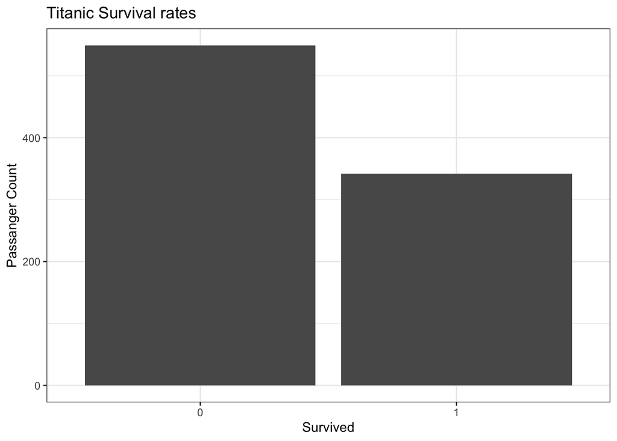

```r
ggplot(titanic, aes(x = Survived)) +
  geom_bar() +
  theme_bw() +
  labs(y = "Passanger Count", title = "Titanic Survival rates")
```

Most people perished on the titanic.

Secondly, what was the survival rate by gender?

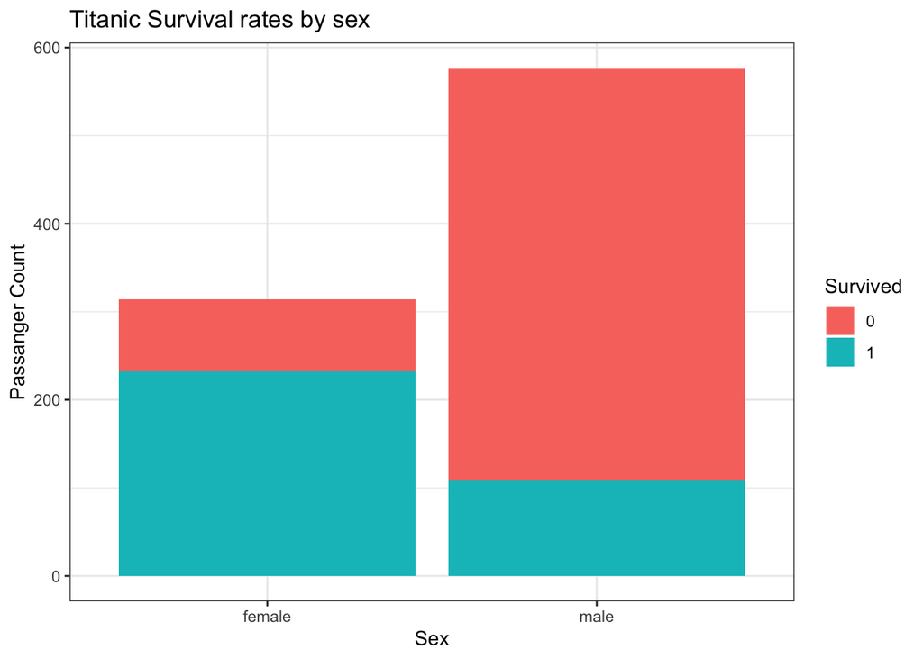

```r
ggplot(titanic, aes(x = Sex, fill = Survived)) +
  geom_bar() +
  theme_bw() +
  labs(y = "Passanger Count", title = "Titanic Survival rates by sex")
```

As expected, disproportionately more women survived than men.

Thirdly, what was the survival rate by ticket class?

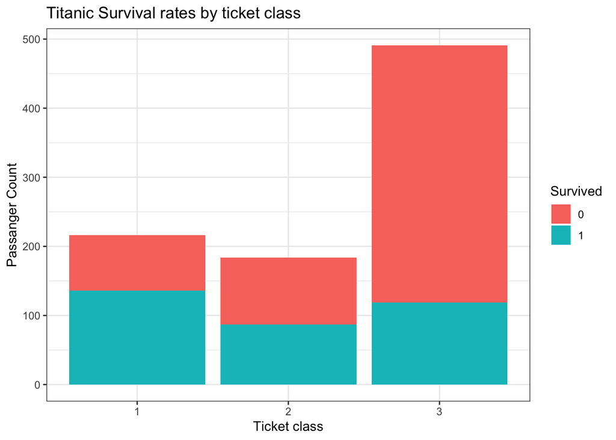

```r
ggplot(titanic, aes(x = Pclass, fill = Survived)) +
  geom_bar() +
  theme_bw() +
  labs(x = "Ticket class",
    y = "Passanger Count", title = "Titanic Survival rates by ticket class")
```

Most people in third class, i.e. the cheapest tickets, and in first class, more than half survived, men and women. Also, interestingly enough, from this chart we see that 3rd class tickets were sold the most, approx. 500, as expected, however second class tickets were sold less than first class.

Next we will see out of the passenger ticket class, how many of the survived where women and how many were men.

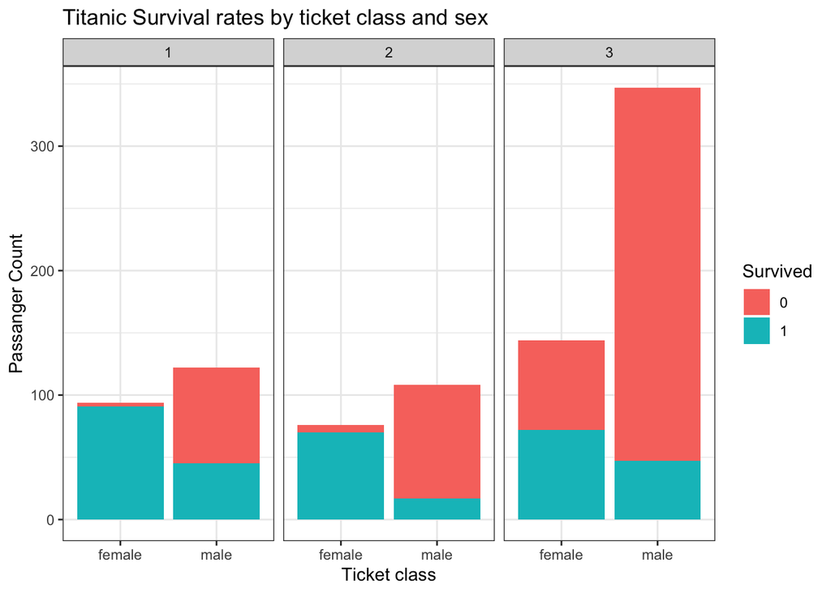

```r
ggplot(titanic, aes(x = Sex, fill = Survived)) +
  geom_bar() +
  facet_wrap(~ Pclass) +
  theme_bw() +
  labs(x = "Ticket class",
    y = "Passanger Count", title = "Titanic Survival rates by ticket class and sex")
```

As expected, women survived in each class disproportionately more than men, where men survived the most in first class, and females in first and second class overwhelmingly survived, whereas in third, only about half survived.

Now we analyse age and its impact on survival rates.

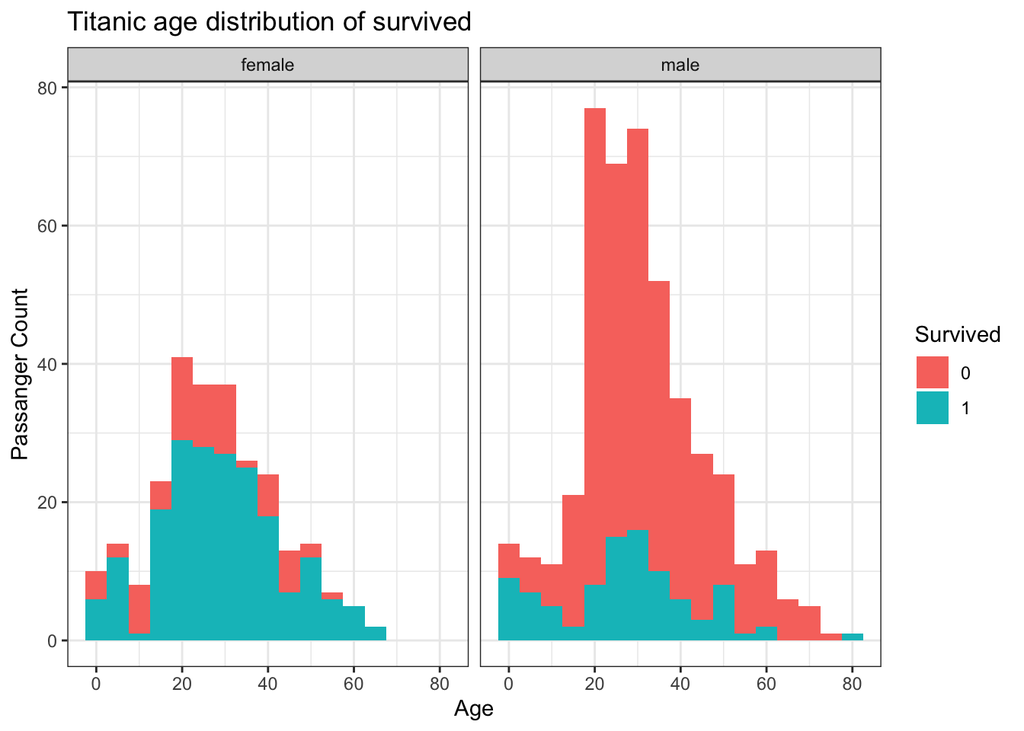

```r
ggplot(titanic, aes(x = Age, fill = Survived)) +
  geom_histogram(binwidth = 5) +
  facet_wrap(~ Sex) +
  theme_bw() +
  labs(x = "Age",
    y = "Passanger Count", title = "Titanic age distribution of survived")
```

Finally, we could create a density plot to see survival rate of population based on gender, age and class ticket.

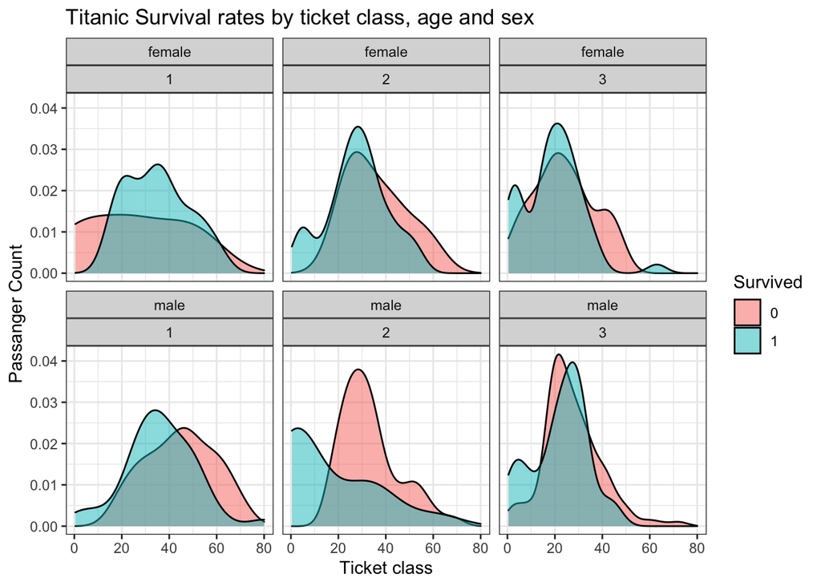

```r
ggplot(titanic, aes(x = Age, fill = Survived)) +
  facet_wrap(Sex ~ Pclass) +
  theme_bw() +
  geom_density(alpha = 0.5) +

  labs(x = "Ticket class",
    y = "Passanger Count", title = "Titanic Survival rates by ticket class, age and sex")
```